# Bellabeat Case Study

Jenny

8/19/2021

## Introduction and background

Bellabeat is a high-tech company that manufactures health-focused smart product for women. The Comapny collects data on Activity, Sleep, Stress and Reproductive Health. The Company uses traditional advertising media, but focuses on digital marketing extensively (Google Search, Facebook, Instagram, Youtube and Twitter). In this scenario I will be playing a role of Junior Data Analyst and will present my analysis to the Bellabeart executive team along with my recommendations for Bellabeat’s team marketing strategy. I will analyze smart device usage data in order to gain insight into how consumers use non-Bellabeat smart devices. These questions will guide my analysis: What are some trends in smart device usage? How could these trends apply to Bellabeat customers? How could these trends help influence Bellabeat marketing strategy?

For the purpose of this research I was encouraged to use following public data: FitBit Fitness Tracker Data (CC0: Public Domain, dataset made available through Mobius): This Kaggle data set contains personal fitness tracker from thirty fitbit users. Thirty eligible Fitbit users consented to the submission of personal tracker data, including minute-level output for physical activity, heart rate, and sleep monitoring. It includes information about daily activity, steps, and heart rate that can be used to explore users’ habits. After brief exploration of the dataset, I can suggest that Data is Reliable, Original, Comprehensive, Current and Cited.

## Installing and loading common packages and libraries

```r
install.packages('tidyverse', repos = "http://cran.us.r-project.org")
```

```r
install.packages('ggplot2', repos = "http://cran.us.r-project.org")
install.packages('ggthemes', repos ="http://cran.us.r-project.org")
library(tidyverse)  #helps wrangle data
library(ggplot2)  #helps visualize data
library(ggthemes)
getwd() #displays my working directory
```

```
## [1] "/Users/jn/Case-study/CSV/Bellabeat-Case-Study"
```

```r
setwd("//Users/jn/Case-study/CSV/Bellabeat-Case-Study")
```

### STEP 1: COLLECT DATA

```r
daily_activity <- read.csv("dailyActivity_merged.csv")
sleep_day <- read.csv("sleepDay_merged.csv")
```

### STEP 2: Exploring a few key tables

Take a look at the daily_activity data.

```r
head(daily_activity)
```

```
##           Id ActivityDate TotalSteps TotalDistance TrackerDistance
## 1 1503960366    4/12/2016      13162          8.50            8.50
## 2 1503960366    4/13/2016      10735          6.97            6.97
## 3 1503960366    4/14/2016      10460          6.74            6.74
## 4 1503960366    4/15/2016       9762          6.28            6.28
## 5 1503960366    4/16/2016      12669          8.16            8.16
## 6 1503960366    4/17/2016       9705          6.48            6.48
##   LoggedActivitiesDistance VeryActiveDistance ModeratelyActiveDistance
## 1                        0               1.88                     0.55
## 2                        0               1.57                     0.69
## 3                        0               2.44                     0.40
## 4                        0               2.14                     1.26
## 5                        0               2.71                     0.41
## 6                        0               3.19                     0.78
##   LightActiveDistance SedentaryActiveDistance VeryActiveMinutes
## 1                6.06                       0                25
## 2                4.71                       0                21
## 3                3.91                       0                30
## 4                2.83                       0                29
## 5                5.04                       0                36
## 6                2.51                       0                38
##   FairlyActiveMinutes LightlyActiveMinutes SedentaryMinutes Calories
## 1                  13                  328              728     1985
## 2                  19                  217              776     1797
## 3                  11                  181             1218     1776
## 4                  34                  209              726     1745
## 5                  10                  221              773     1863
## 6                  20                  164              539     1728
```

Identify all the columsn in the daily_activity data.

```r
colnames(daily_activity)
```

```
##  [1] "Id"                       "ActivityDate"
##  [3] "TotalSteps"               "TotalDistance"
##  [5] "TrackerDistance"          "LoggedActivitiesDistance"
##  [7] "VeryActiveDistance"       "ModeratelyActiveDistance"
##  [9] "LightActiveDistance"      "SedentaryActiveDistance"
## [11] "VeryActiveMinutes"        "FairlyActiveMinutes"
## [13] "LightlyActiveMinutes"     "SedentaryMinutes"
## [15] "Calories"
```

Take a look at the sleep_day data.

```r
head(sleep_day)
```

```
##           Id              SleepDay TotalSleepRecords TotalMinutesAsleep
## 1 1503960366 4/12/2016 12:00:00 AM                 1                327
## 2 1503960366 4/13/2016 12:00:00 AM                 2                384
## 3 1503960366 4/15/2016 12:00:00 AM                 1                412
## 4 1503960366 4/16/2016 12:00:00 AM                 2                340
## 5 1503960366 4/17/2016 12:00:00 AM                 1                700
## 6 1503960366 4/19/2016 12:00:00 AM                 1                304
##   TotalTimeInBed
## 1            346
## 2            407
## 3            442
## 4            367
## 5            712
## 6            320
```

Identify all the columsn in the daily_activity data.

```r
colnames(sleep_day)
```

```
## [1] "Id"                 "SleepDay"           "TotalSleepRecords"
## [4] "TotalMinutesAsleep" "TotalTimeInBed"
```

Note that both datasets have the ‘Id’ field - this can be used to merge the datasets.

### STEP 3: Understanding some summary statistics

How many unique participants are there in each dataframe?

```r
n_distinct(daily_activity$Id)
```

```
## [1] 33
```

```r
n_distinct(sleep_day$Id)
```

```
## [1] 24
```

There more participants in the daily activity dataset than the sleep dataset. The dataset contains information about 33 unique users and not 30 as advised initially. By all means sample size is not sufficient enough to provide accurate results. Within available data we see that Fitbit users do not use sleep-related and heart-related features as often as step and calories calculator. There is no information in relation to gender identity of the participants hence data analysis cannot be used to influence menstrual cycle-related products of the company. Data does not contain information about water consumption.

How many observations are there in each dataframe?

```r
nrow(daily_activity)
```

```
## [1] 940
```

```r
nrow(sleep_day)
```

```
## [1] 413
```

What are some quick summary statistics we’d want to know about each data frame?

For the daily activity dataframe:

```r
daily_activity %>%
  select(TotalSteps,
         TotalDistance,
         SedentaryMinutes) %>%
  summary()
```

```
##    TotalSteps    TotalDistance    SedentaryMinutes
##  Min.   :    0   Min.   : 0.000   Min.   :   0.0
##  1st Qu.: 3790   1st Qu.: 2.620   1st Qu.: 729.8
##  Median : 7406   Median : 5.245   Median :1057.5
##  Mean   : 7638   Mean   : 5.490   Mean   : 991.2
##  3rd Qu.:10727   3rd Qu.: 7.713   3rd Qu.:1229.5
##  Max.   :36019   Max.   :28.030   Max.   :1440.0
```

For the sleep dataframe:

```r
sleep_day %>%
  select(TotalSleepRecords,
  TotalMinutesAsleep,
  TotalTimeInBed) %>%
  summary()
```

```
##  TotalSleepRecords TotalMinutesAsleep TotalTimeInBed
##  Min.   :1.000     Min.   : 58.0      Min.   : 61.0
##  1st Qu.:1.000     1st Qu.:361.0      1st Qu.:403.0
##  Median :1.000     Median :433.0      Median :463.0
##  Mean   :1.119     Mean   :419.5      Mean   :458.6
##  3rd Qu.:1.000     3rd Qu.:490.0      3rd Qu.:526.0
##  Max.   :3.000     Max.   :796.0      Max.   :961.0
```

What does this tell us about how this sample of people’s activities?

### STEP 4: Plotting a few explorations

### What’s the relationship between steps taken in a day and sedentary minutes?

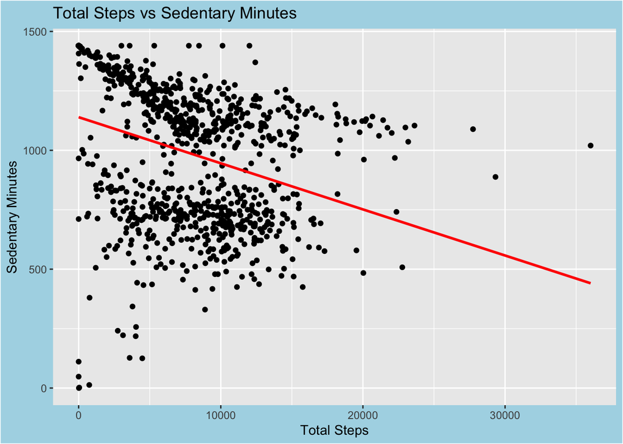

```r
ggplot(data=daily_activity, aes(x=TotalSteps, y=SedentaryMinutes)) + geom_point() +
labs(title = "Total Steps vs Sedentary Minutes")+
  xlab("Total Steps")+ylab("Sedentary Minutes")+
  geom_smooth(method = "lm", se = FALSE, color = "red") +
  theme(plot.background = element_rect(fill = "lightblue"))
```

### Scatter plot of changes in steps/day and changes in minutes of Sedentary.

What’s the relationship between minutes asleep and time in bed? You might expect it to be almost completely linear - are there any unexpected trends?

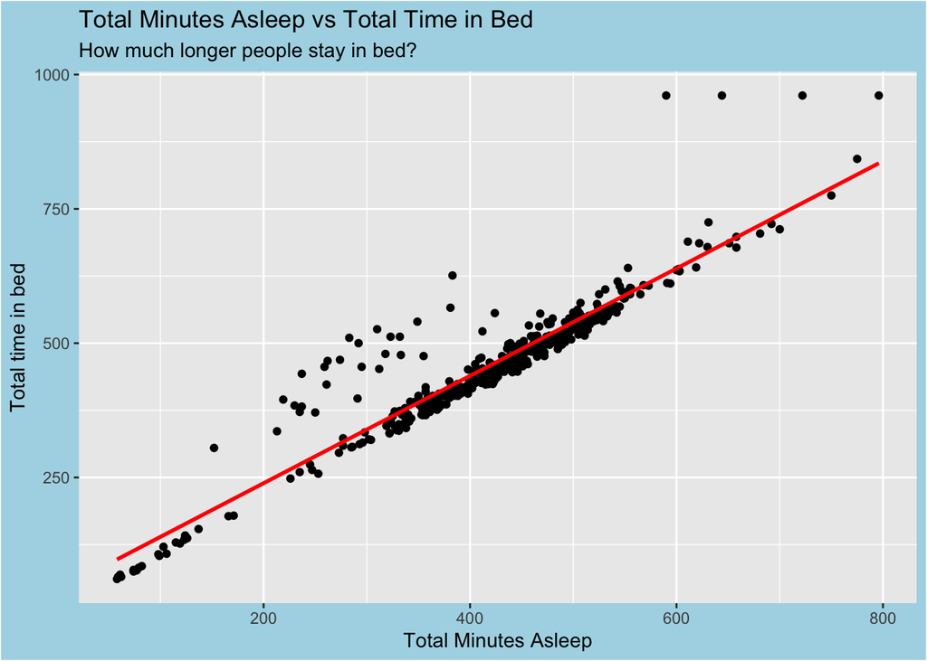

```r
ggplot(data=sleep_day, aes(x=TotalMinutesAsleep, y=TotalTimeInBed)) + geom_point()+
labs(title = "Total Minutes Asleep vs Total Time in Bed",subtitle = "How much longer people stay in bed?")+
  xlab("Total Minutes Asleep")+ylab("Total time in bed")+
  geom_smooth(method = "lm", se = FALSE, color = "red") +
  theme(plot.background = element_rect(fill = "lightblue"))
```

### STEP 5: Merging these two datasets together

```r
combined_data <- merge(sleep_day, daily_activity, by="Id")
```

Take a look at how many participants are in this data set.

```r
n_distinct(combined_data$Id)
```

```
## [1] 24
```

## RECOMMENDATIONS

- In order to provide more detailed and accurate data information, Bellabeat should collect their data or use an external data with at least 377 participants. This will allow to gain 95% confidence with a 5% margin error for the population size over 20000.
- Moreover, it is important to receive information as accurate as possible. My suggestion is put additional effort into collecting and recording data to avoid discrepancy in amount of steps. After such development it is suggested to use the “accuracy” advantage in marketing strategy for Bellabeat Leaf and Bellabeat app. Such an advantage may increase the amount of sales for women.
- Based on Fibit’s data we clearly see that people tends to use smart watch to calculate their step and calories more often than sleep tracker. Possibly it is connected with the fact that they charge their devices at night and it is impossible to make an entry to the log. I would suggest to provide Bellabeat app, Leaf and Time with an upgrade that will allow to track and monitor the movement while people are asleep. This automotive process will allow to receive more data about the users without enforcing customers to enter data manually.
- It is clear from the graph that significant part of the participants stay in bed even when they are awake. Considering that there is a big chance that they are using their phones while being awake it is suggested to allow Leaf and Bellabeat app to provide a notification to drink more water. Since it is already established that the person is awake, the smart-bottle can make a reminder itself.
- From the first graph we clearly see that if we walk more, it will help reduce the amount of time we spend sedentary each day. Besides, encouraging people to walk more, we also encourage them to exercise more and to consume more water. So we can think about develop additional drink water notifications and reminders will positively influence both sales of the company and general health of the population.